# Fish Market Short Analysis

Murat Can Taşar

10/25/2021

## Brief Analysis

This is a brief analysis of fish market dataset. First we start by loading the necessary libraries.

```r
library(tidyverse)
library(lubridate)
```

```r
library(ggplot2)
```

Second, we read the dataset with the read_csv command. Don’t forget that our delimiter is “;”, so we have to specify it. Also, our dataset contains Turkish characters, thus we also have to specify an encoding argument.

```r
fish <- read.csv("C:/Users/mctas/Desktop/MEF_BDA/R/balik_hal_fiyatlari.csv", sep=';', encoding = 'UTF-8')
```

Then, we pipe our dataset into a view.

```r
fish %>% View()
```

If we get a glimpse of our dataframe, fish:

```r
glimpse(fish)
```

```
## Rows: 18,596
## Columns: 6
## $ TARIH        <chr> "2021-01-02 00:00:00", "2021-01-02 00:00:00", "2021-01-02~
## $ MAL_TURU     <chr> "BALIK", "BALIK", "BALIK", "BALIK", "BALIK", "BALIK", "BA~
## $ MAL_ADI      <chr> "TIRSI (DENIZ)", "KIRLANGIÇ (DENIZ)", "ÇIMÇIM (DENIZ)", "~
## $ BIRIM        <chr> "KG", "KG", "KG", "KG", "KG", "KG", "KG", "KG", "KG", "KG~
## $ ASGARI_UCRET <dbl> 5.83, 3.00, 3.50, 2.50, 45.00, 130.00, 38.00, 25.00, 10.0~
## $ AZAMI_UCRET  <dbl> 12.50, 80.00, 8.00, 5.00, 45.00, 130.00, 38.00, 55.00, 10~
```

As you can see, our date column is type character. We have to convert it into datetime by using the command below.

```r
fish$TARIH <- ymd_hms(fish$TARIH)
```

Let’s check the minimum and maximum dates in the dataframe.

```r
min(fish$TARIH)
```

```
## [1] "2021-01-02 UTC"
```

```r
max(fish$TARIH)
```

```
## [1] "2021-10-21 UTC"
```

Also, let’s have a general idea about the minimum and maximum mean prices of fish overall. This table shows us the overall mean prices of different products, including regular fish, imported fish etc.

```r
ortalama_ucretler <- fish %>% group_by(MAL_TURU) %>% summarise(ASGARI_UCRET_ORTALAMA=mean(ASGARI_UCRET), AZAMI_UCRET_ORTALAMA=mean(AZAMI_UCRET))
ortalama_ucretler
```

```
## # A tibble: 4 x 3
##   MAL_TURU      ASGARI_UCRET_ORTALAMA AZAMI_UCRET_ORTALAMA
##   <chr>                         <dbl>                <dbl>
## 1 BALIK                          30.9                 68.4
## 2 ITHAL (DONUK)                  24.4                 30.8
## 3 KÜLTÜR                         22.2                 64.6
## 4 TATLI SU                       29.6                 35.8
```

If we want to check out daily minimum and maximum mean prices of all fish products, we get the following dataframe.

```r
historic_fish_prices <- fish %>% group_by(TARIH) %>% summarise(ASGARI_gunluk_ortalama=mean(ASGARI_UCRET), AZAMI_gunluk_ortalama=mean(AZAMI_UCRET))
historic_fish_prices
```

```
## # A tibble: 284 x 3
##    TARIH               ASGARI_gunluk_ortalama AZAMI_gunluk_ortalama
##    <dttm>                               <dbl>                 <dbl>
##  1 2021-01-02 00:00:00                   21.1                  36.7
##  2 2021-01-03 00:00:00                   19.5                  51.1
##  3 2021-01-04 00:00:00                   23.3                  48.4
##  4 2021-01-05 00:00:00                   26.2                  49.7
##  5 2021-01-06 00:00:00                   21.8                  46.7
##  6 2021-01-07 00:00:00                   23.8                  60.3
##  7 2021-01-08 00:00:00                   21.1                  51.8
##  8 2021-01-09 00:00:00                   21.9                  43.8
##  9 2021-01-10 00:00:00                   22.3                  44.9
## 10 2021-01-11 00:00:00                   20.0                  49.6
## # ... with 274 more rows
```

Let’s add two more columns to this dataframe. These columns should represent the overall minimum and maximum mean prices of all fish.

```r
historic_fish_prices$ASGARI_tum_zamanlar_ortalama <- mean(historic_fish_prices$ASGARI_gunluk_ortalama)
historic_fish_prices$AZAMI_tum_zamanlar_ortalama <- mean(historic_fish_prices$AZAMI_gunluk_ortalama)
```

```r
mean(historic_fish_prices$ASGARI_gunluk_ortalama)
```

```
## [1] 30.74063
```

```r
mean(historic_fish_prices$AZAMI_gunluk_ortalama)
```

```
## [1] 65.42487
```

Let’s plot the historic data of fish prices using the library reshape2.

```r
library(reshape2)
```

```r
historic_fish_prices.long <- melt(historic_fish_prices, id = "TARIH",
                                  measure = c("ASGARI_tum_zamanlar_ortalama",
                                                      "AZAMI_gunluk_ortalama",
                                                      "ASGARI_gunluk_ortalama",
                                                      "AZAMI_tum_zamanlar_ortalama"))
```

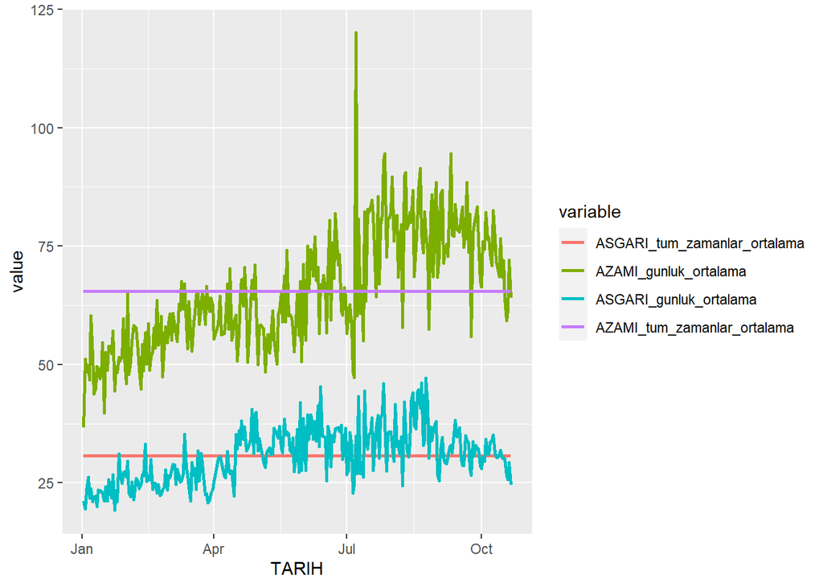

```r
ggplot(historic_fish_prices.long, aes(TARIH, value, colour = variable)) + geom_line(size=1)
```